# Economic Outlook Report

Nandhini Sureshkumar

2025-05-04

## Data Description

For this project, I analyzed US retail sales data to explore recent trends and build forecasting models using time series techniques. The datasets were sourced from the Federal Reserve Economic Data (FRED) platform, covering multiple retail sectors from 2000 to 2024. I focused on the following retail categories:

- Retail Trade and Food Services
- Clothing and Accessories Stores
- Furniture and Home Furnishings Stores

Additional variables used to enrich the analysis include:

- Consumer Price Index (CPI) from FRED, representing inflationary pressure

Google Trends search interest for:

- “restaurants” (for food services)
- “clothing” (for apparel and accessories)
- “furnish” (for furniture and furnishings)

These external signals were joined to assess whether macroeconomic trends and consumer online behavior correlate with retail performance across different sectors.

## Research Objective

The main goal of this project is to understand and forecast retail sales behavior in the US. Specifically, I ask:

- How well can we model and forecast sales for different retail sectors such as food services, clothing, and furniture?
- Do external indicators like CPI or Google Trends improve forecasting accuracy, and does their impact vary by category?
- Which models (ARIMA, ETS, TSLM with Fourier terms, or ARIMA with external regressors) deliver the most accurate forecasts for each retail segment?
- This multi-sectoral approach allows us to identify whether modeling strategies need to be customized based on the nature of the retail category.

## Data Extraction & Data Cleaning

To begin the analysis, I collected monthly retail sales data from the Federal Reserve Economic Data (FRED) platform. This included key retail sectors: Food Services, Clothing, and Furniture. Additionally, I incorporated the Consumer Price Index (CPI) to account for inflation and Google Trends data to reflect real-time consumer interest. Specifically, I used search terms such as:

- “restaurants” for Food Services,
- “clothing” for Clothing, and
- “furnish” for Furniture.

Once imported, each dataset was cleaned and standardized. This involved formatting date fields into a consistent yearmonth format, scaling sales values to billions for readability, and converting them into tsibble structures for time series analysis. All datasets were then aligned by month to allow for proper merging and consistent modeling across variables and sectors.

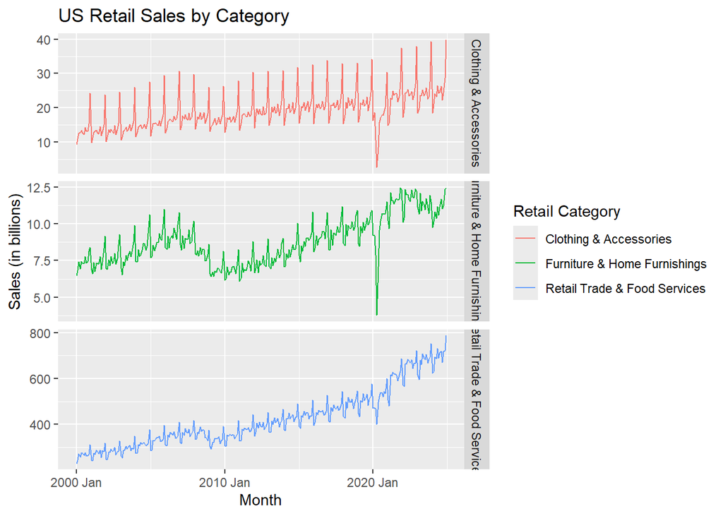

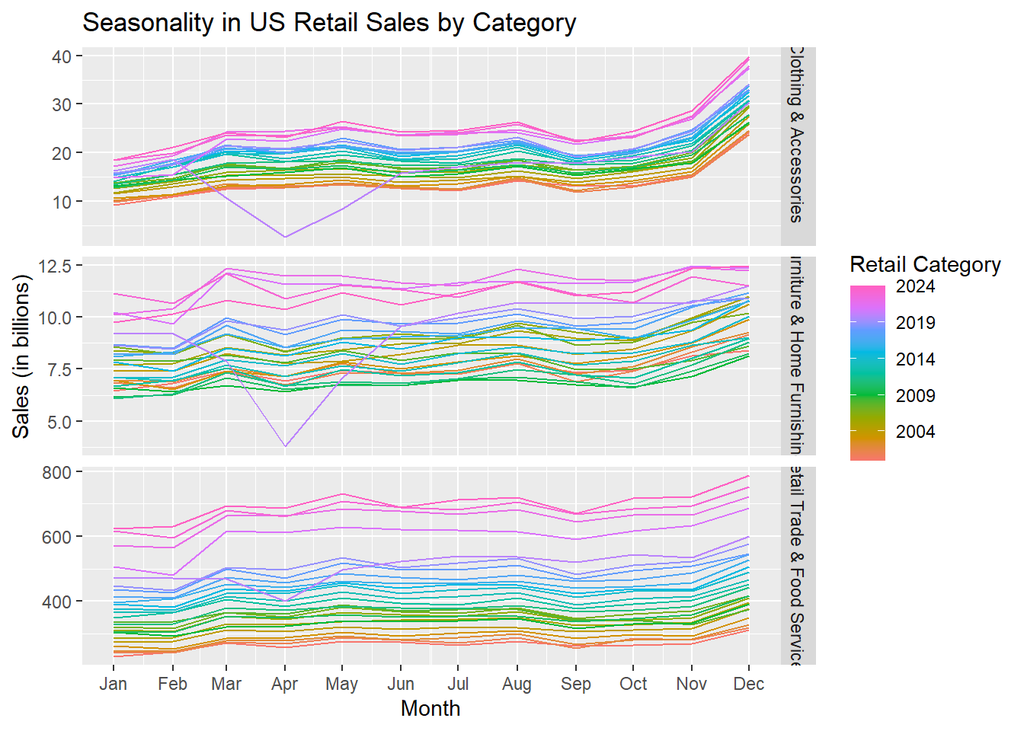

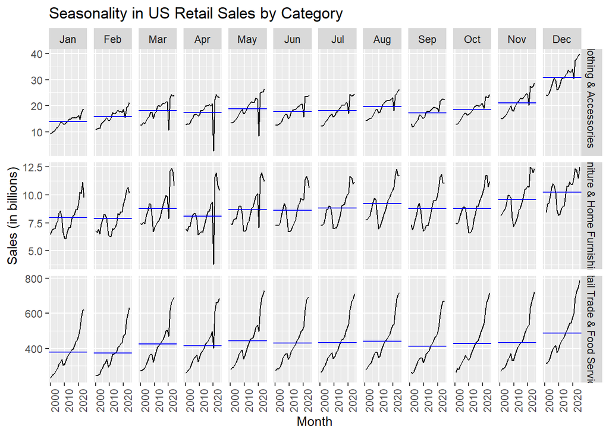

## Visualizations and Decomposition

### Retail Trade and Food Services

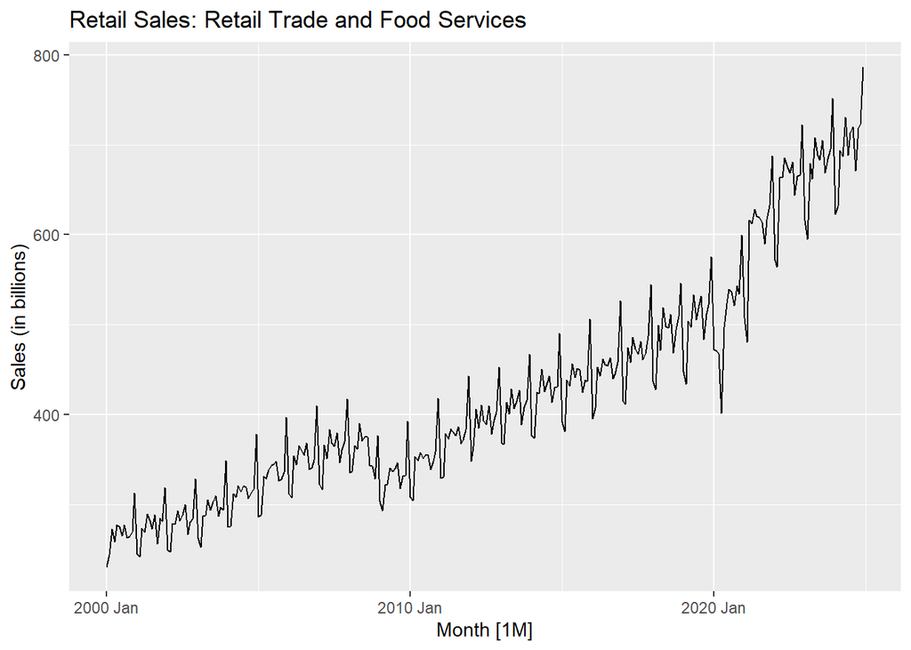

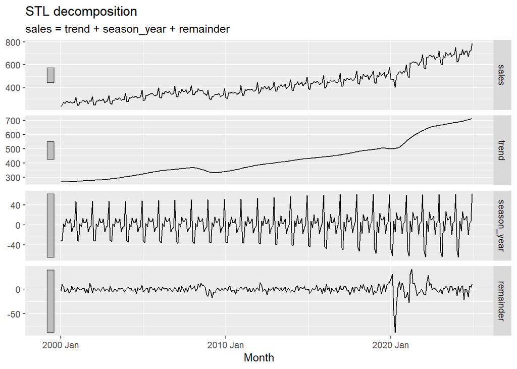

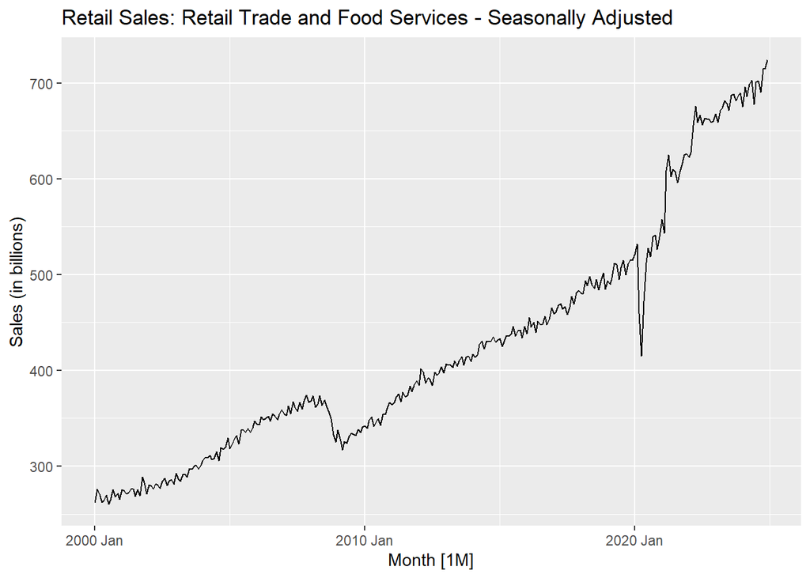

#### Differeneced Data For Stationarity

This section will discuss the auto-correlation, and partial auto-correlation function plots (ACF/PACF), these plots allowed for the estimation of our performed forecasts.

#### First Difference (Full-Sample)

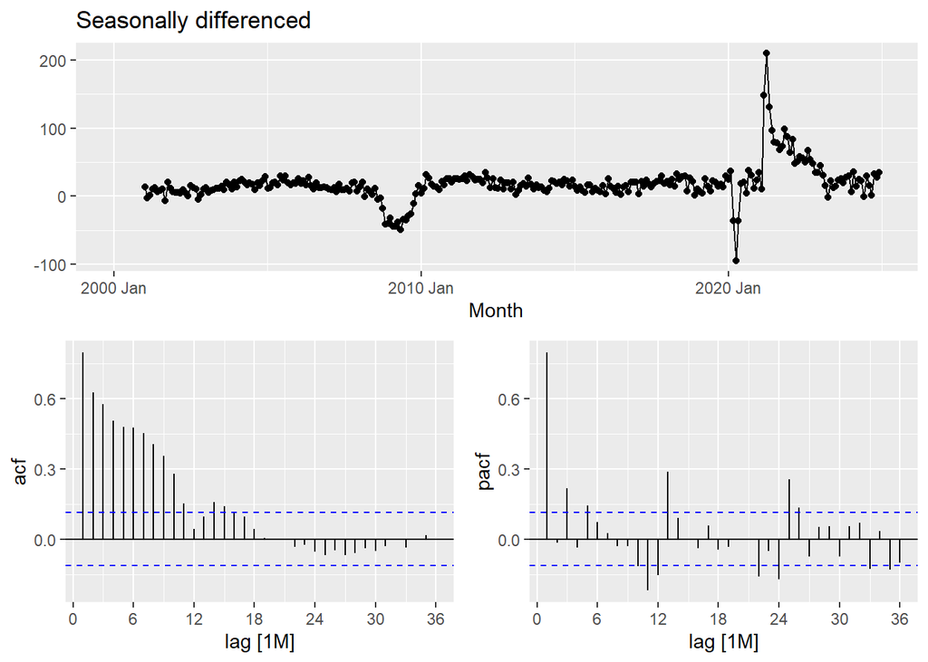

These are also clearly non-stationary, so we take a further first difference

#### Double Difference (Full-Sample)

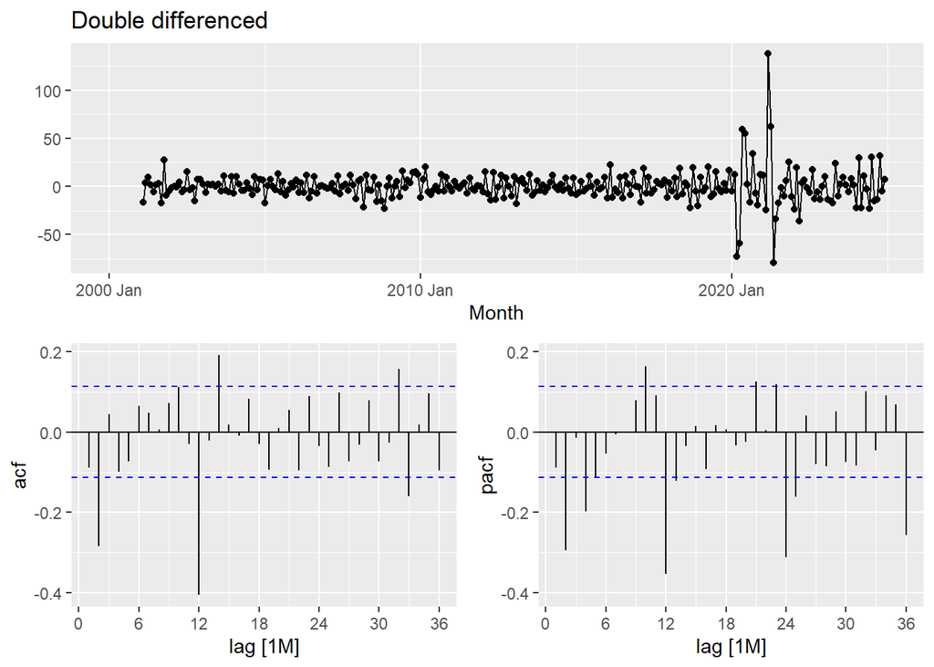

The appropriate ARIMA model based on the ACF and PACF:

First Model : ARIMA(0,1,2)(0,1,1)12

- The significant spike at lag 2 in the ACF suggests a non-seasonal MA(2) component.
- The significant spike at lag 12 in the ACF suggests a seasonal MA(1) component.
- So, we begin with an ARIMA(0,1,2)(0,1,1)12 model, indicating a first difference, a seasonal difference, and non-seasonal MA(2) and seasonal MA(1) component.

Second Model : ARIMA(2,1,0)(0,1,1)12

- With PACF, we may have an ARIMA(2,1,0)(0,1,1) 12 model — using the PACF to select the non-seasonal part of the model and the ACF to select the seasonal part of the model.

Third Model : ARIMA(2,1,0)(1,1,0)12

- The significant spike at lag 2 in the PACF suggests a non-seasonal AR(2) component.
- The significant spike at lag 12 in the ACF suggests a seasonal AR(1) component.
- So, an ARIMA(2,1,0)(1,1,0)12 model, indicating a first difference, a seasonal difference, and non-seasonal AR(2) and seasonal AR(1) component.

### Clothing and Clothing Accessory Stores

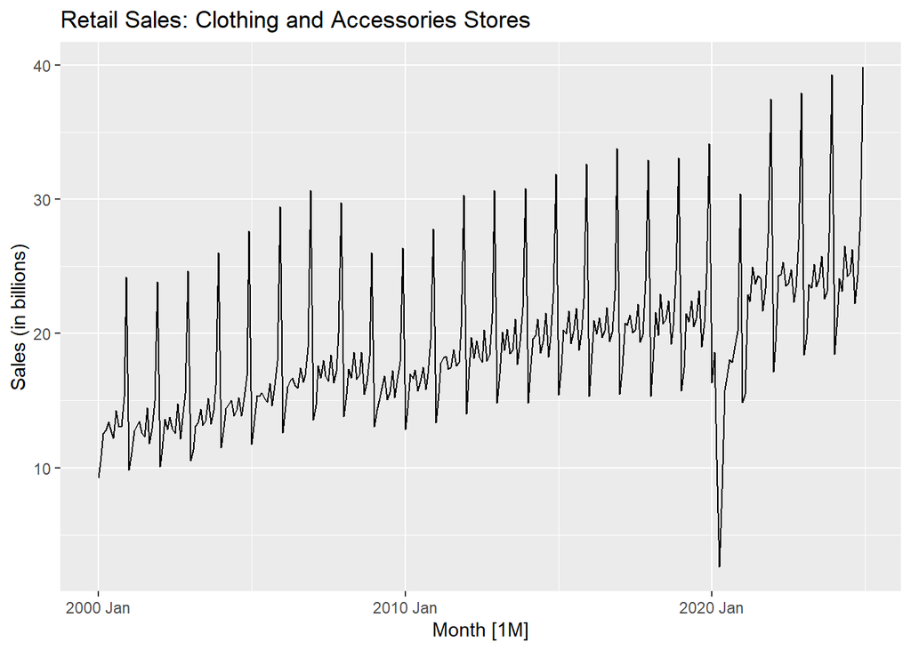

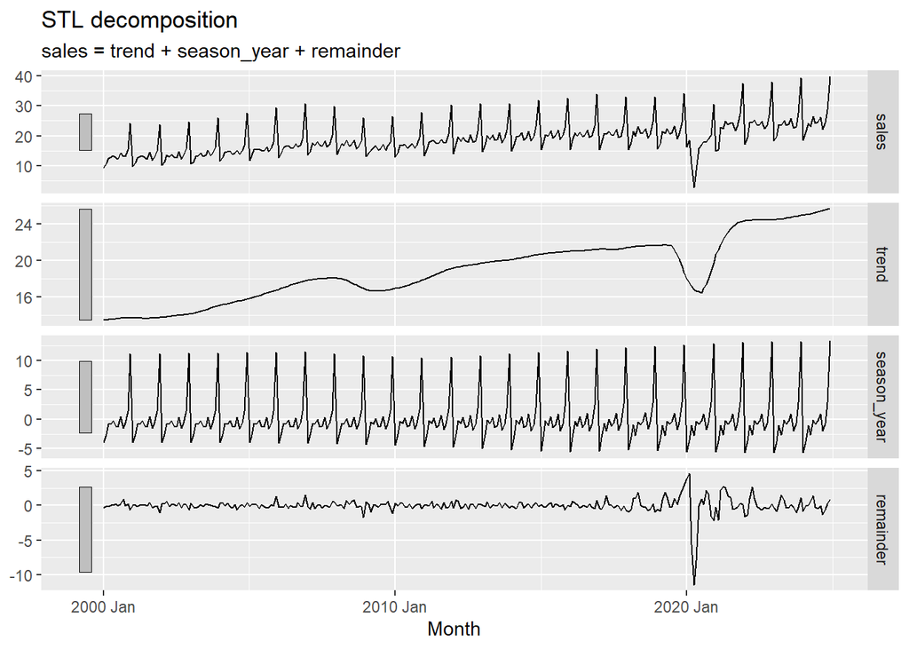

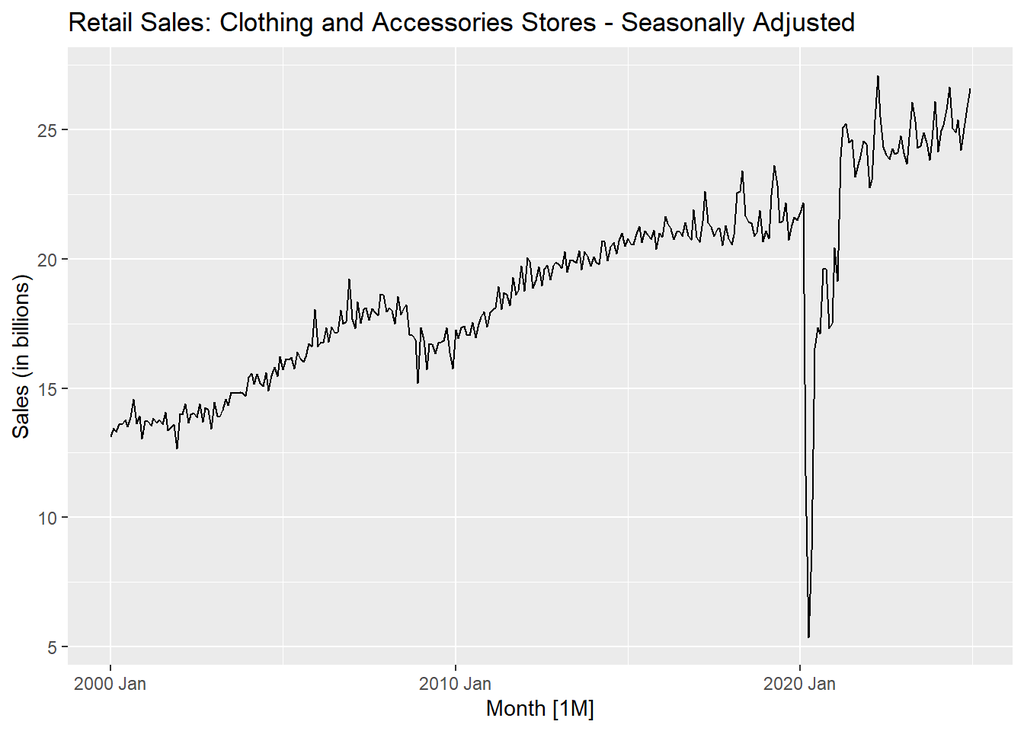

#### Differeneced Data For Stationarity

This section will discuss the auto-correlation, and partial auto-correlation function plots (ACF/PACF), these plots allowed for the estimation of our performed forecasts.

#### First Difference (Full-Sample)

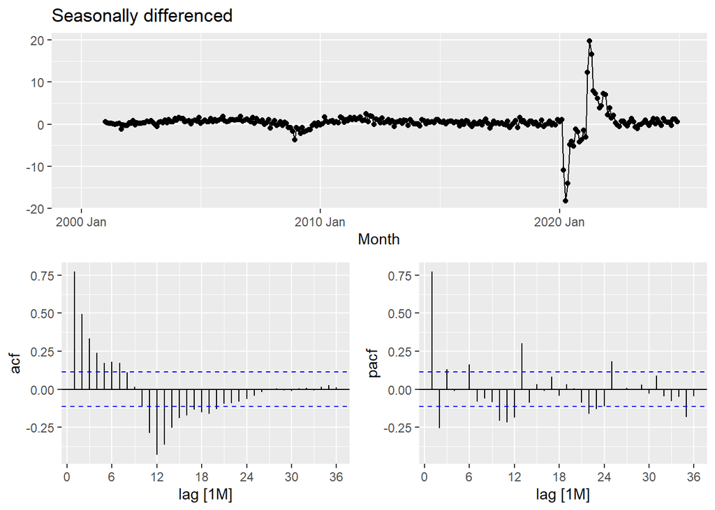

These are also clearly non-stationary, so we take a further first difference

#### Double Difference (Full-Sample)

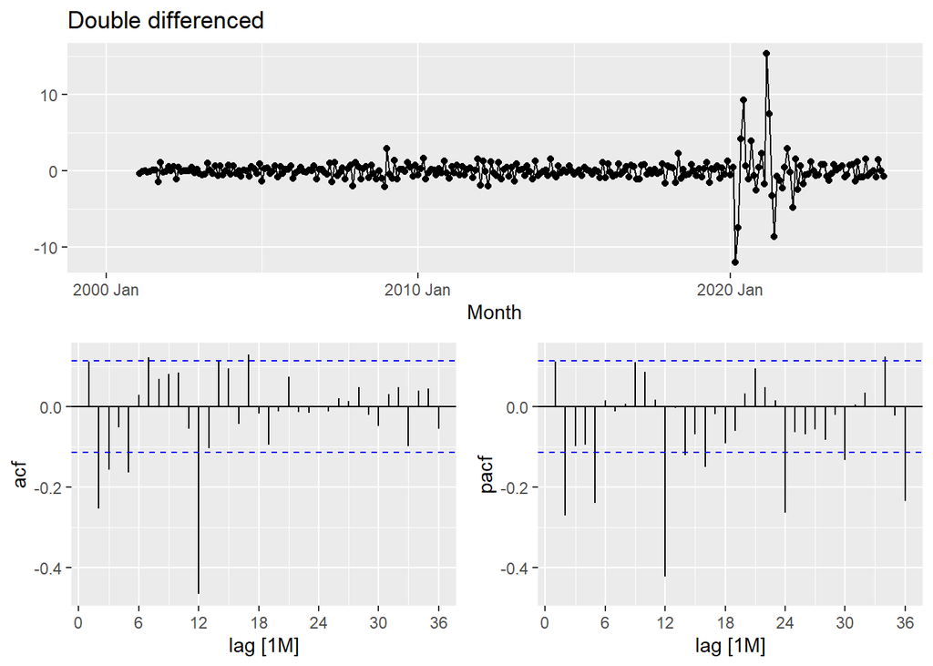

The appropriate ARIMA model based on the ACF and PACF:

First Model : ARIMA(0,1,2)(0,1,1)12

- The significant spike at lag 2 in the ACF suggests a non-seasonal MA(2) component.
- The significant spike at lag 12 in the ACF suggests a seasonal MA(1) component.
- So, we begin with an ARIMA(0,1,2)(0,1,1)12 model, indicating a first difference, a seasonal difference, and non-seasonal MA(2) and seasonal MA(1) component.

Second Model : ARIMA(2,1,0)(0,1,1)12

- With PACF, we may have an ARIMA(2,1,0)(0,1,1) 12 model — using the PACF to select the non-seasonal part of the model and the ACF to select the seasonal part of the model.

Third Model : ARIMA(2,1,0)(1,1,0)12

- The significant spike at lag 2 in the PACF suggests a non-seasonal AR(2) component.
- The significant spike at lag 12 in the ACF suggests a seasonal AR(1) component.
- So, an ARIMA(2,1,0)(1,1,0)12 model, indicating a first difference, a seasonal difference, and non-seasonal AR(2) and seasonal AR(1) component.

### Furniture and Home Furnishings Stores

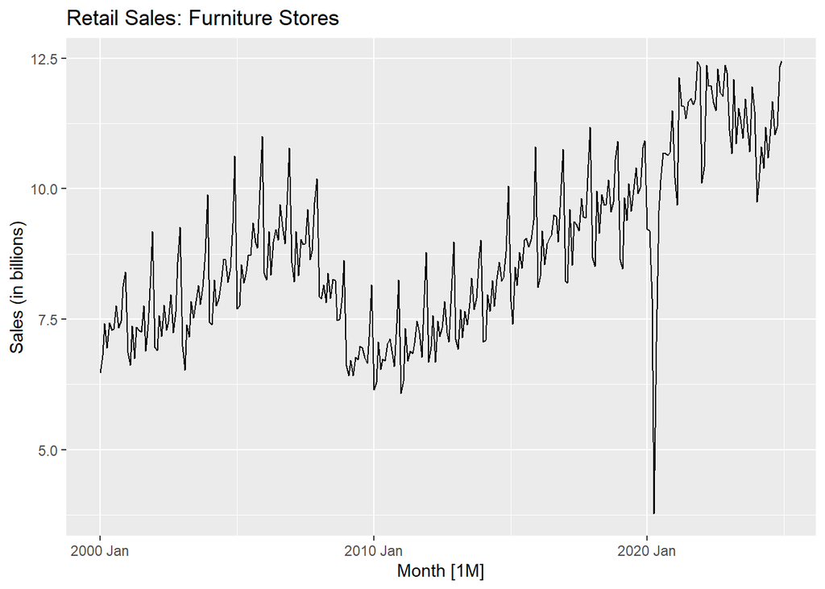

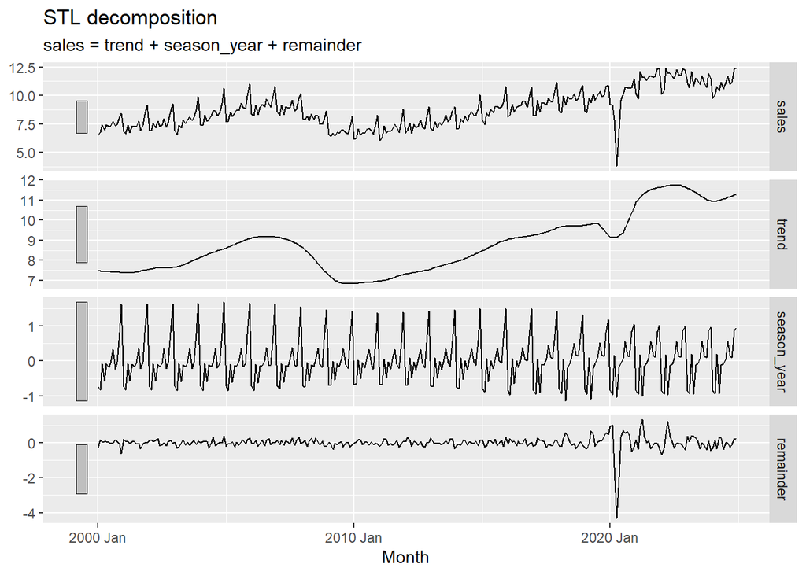

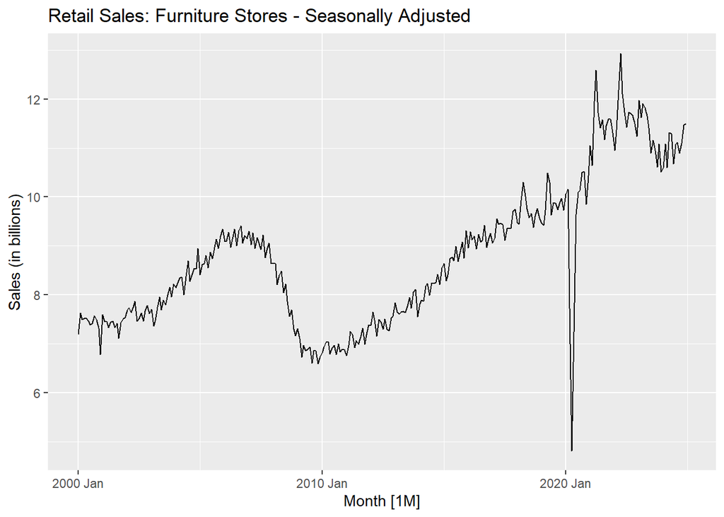

#### Differeneced Data For Stationarity

This section will discuss the auto-correlation, and partial auto-correlation function plots (ACF/PACF), these plots allowed for the estimation of our performed forecasts.

#### First Difference (Full-Sample)

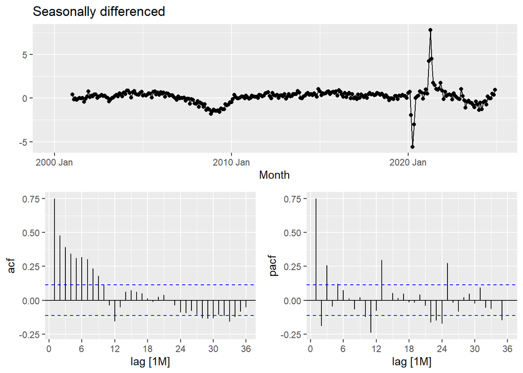

These are also clearly non-stationary, so we take a further first difference

#### Double Difference (Full-Sample)

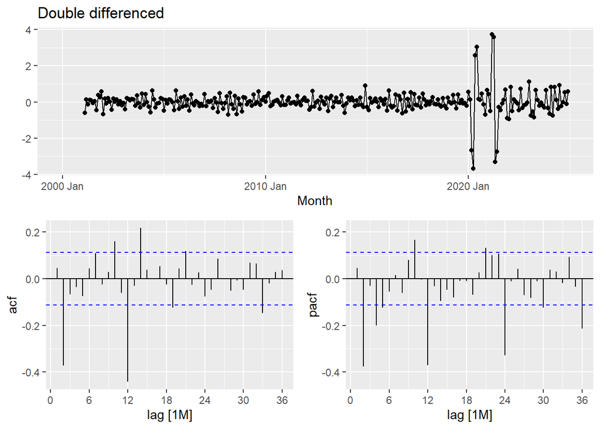

The appropriate ARIMA model based on the ACF and PACF:

First Model : ARIMA(0,1,2)(0,1,1)12

- The significant spike at lag 2 in the ACF suggests a non-seasonal MA(2) component.
- The significant spike at lag 12 in the ACF suggests a seasonal MA(1) component.
- So, we begin with an ARIMA(0,1,2)(0,1,1)12 model, indicating a first difference, a seasonal difference, and non-seasonal MA(2) and seasonal MA(1) component.

Second Model : ARIMA(2,1,0)(0,1,1)12

- With PACF, we may have an ARIMA(2,1,0)(0,1,1) 12 model — using the PACF to select the non-seasonal part of the model and the ACF to select the seasonal part of the model.

Third Model : ARIMA(2,1,0)(1,1,0)12

- The significant spike at lag 2 in the PACF suggests a non-seasonal AR(2) component.
- The significant spike at lag 12 in the ACF suggests a seasonal AR(1) component.
- So, an ARIMA(2,1,0)(1,1,0)12 model, indicating a first difference, a seasonal difference, and non-seasonal AR(2) and seasonal AR(1) component.

## Model Building

### Retail Trade and Food Services

#### Train - Test Split

I split the dataset into training and test sets. All data before January 2022 was used for training, while data from January 2022 onwards was reserved for testing. This setup allows for an honest evaluation of the forecasting models’ ability to generalize.

I also visualized the training data across the three variables to observe any discrepancies in trends and seasonality, which helped validate the relationships among these features before fitting time series models.

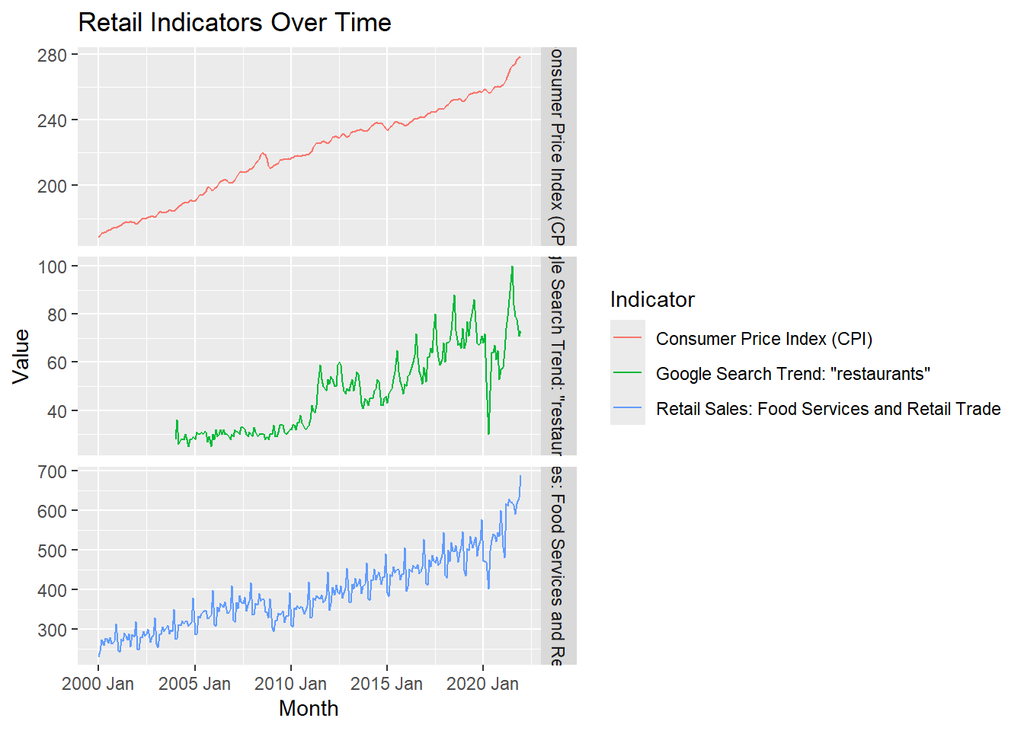

Retail Sales exhibit strong seasonality with an upward trend, sharply rising after pandemic.

#### Model Fitting

```
# A mable: 10 x 2
# Key:     Model name [10]
   `Model name`                                   Orders
   <chr>                                         <model>
 1 fourier6                                       <TSLM>
 2 ets                                     <ETS(M,Ad,M)>
 3 arima012011                 <ARIMA(0,1,2)(0,1,1)[12]>
 4 arima210011                 <ARIMA(2,1,0)(0,1,1)[12]>
 5 arima210110                 <ARIMA(2,1,0)(1,1,0)[12]>
 6 stepwise                    <ARIMA(1,1,2)(0,1,2)[12]>
 7 arima1                      <ARIMA(0,1,2)(2,1,2)[12]>
 8 arima_cpi      <LM w/ ARIMA(1,1,2)(0,1,2)[12] errors>
 9 arima_google   <LM w/ ARIMA(2,1,0)(2,1,0)[12] errors>
10 arima_fourier6            <LM w/ ARIMA(1,1,2) errors>
```

##### AIC Comparison

```
# A tibble: 10 × 6
   .model             sigma2 log_lik   AIC  AICc   BIC
   <chr>               <dbl>   <dbl> <dbl> <dbl> <dbl>
 1 arima_google   113.         -793. 1599. 1599. 1620.
 2 fourier6       685.        -1230. 1738. 1740. 1788.
 3 arima_cpi      133.         -973. 1960. 1960. 1984.
 4 arima1         144.         -985. 1984. 1985. 2009.
 5 stepwise       149.         -988. 1988. 1988. 2009.
 6 arima012011    152.         -991. 1990. 1990. 2004.
 7 arima210011    156.         -994. 1995. 1996. 2009.
 8 arima210110    178.        -1009. 2026. 2026. 2040.
 9 arima_fourier6 150.        -1024. 2081. 2083. 2138.
10 ets              0.000731  -1342. 2719. 2722. 2784.
```

I fitted multiple models including ARIMA variants, Fourier-based regression, ETS, and models with external regressors like CPI and Google Trends (“restaurants”). Then I compared them using AICc to find the best fit.

From the table, arima_google came out as the best model with the lowest AICc (1599). This shows that incorporating Google Trends data gives the best forecasting performance.

The fourier6 model also performed decently, better than most traditional ARIMA setups but not as good as arima_google.

arima_cpi did better than plain ARIMA, showing CPI has some predictive value, but still not close to Google Trends.

ETS had the worst AICc by far, meaning it didn’t capture the data patterns well, possibly due to its limitations with complex seasonality and external inputs.

Overall using Google Trends as a regressor significantly improves model accuracy. It’s a strong indicator for food-related retail sales, more effective than CPI or seasonal patterns alone.

###### Forecasts: Top 6 Models Ranked by AICc

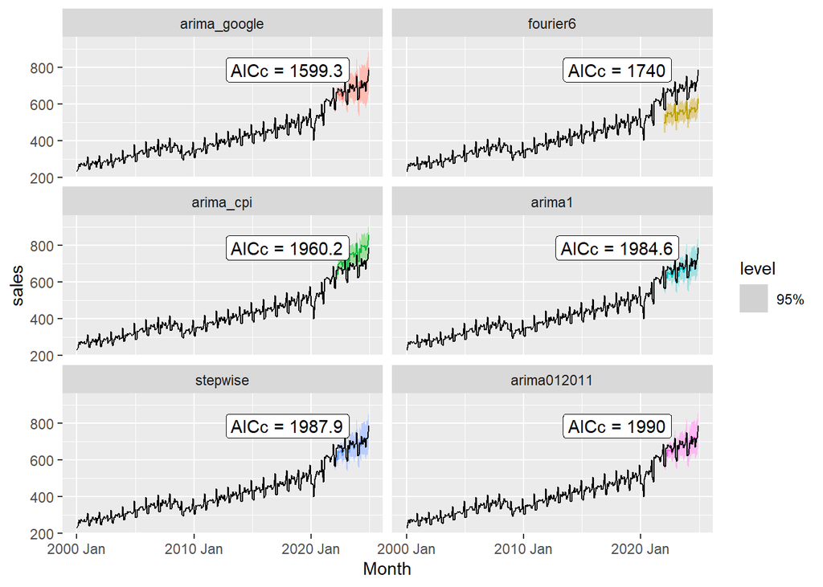

##### Training Data RMSE

```
# A tibble: 10 × 5
   .model         .type     RMSE   MAE  MAPE
   <chr>          <chr>    <dbl> <dbl> <dbl>
 1 arima_cpi      Training  11.1  7.32  1.82
 2 arima_google   Training  11.4  8.27  1.92
 3 arima1         Training  11.5  7.37  1.84
 4 stepwise       Training  11.8  7.69  1.91
 5 arima_fourier6 Training  11.9  7.76  1.98
 6 ets            Training  11.9  7.15  1.75
 7 arima012011    Training  12.0  7.66  1.90
 8 arima210011    Training  12.1  7.63  1.89
 9 arima210110    Training  12.9  8.38  2.07
10 fourier6       Training  25.5 18.1   4.63
```

I evaluated all models based on training RMSE to compare how well they fit the historical data.

arima_cpi performed the best with the lowest RMSE of 11.1, followed closely by arima_google (11.4) and arima1 (11.5). This suggests both CPI and Google Trends are strong predictors of sales, with CPI doing slightly better on training data.

The basic ARIMA models (arima012011, arima210011, arima210310) had higher RMSEs, showing that adding external regressors or using a non-stepwise full ARIMA search improves fit.

The fourier6 model had the worst RMSE (25.5), indicating that trend + seasonality alone isn’t enough for this dataset. ETS surprisingly had a decent RMSE (11.9), though its AIC was high earlier — it fits okay but isn’t the most efficient.

Overall, models with external features (CPI, GOOGLE Trend) outperformed other time series models, highlighting the value of incorporating real-world signals for forecasting accuracy.

###### Forecasts: Top 6 Models Ranked by Training Data RMSE

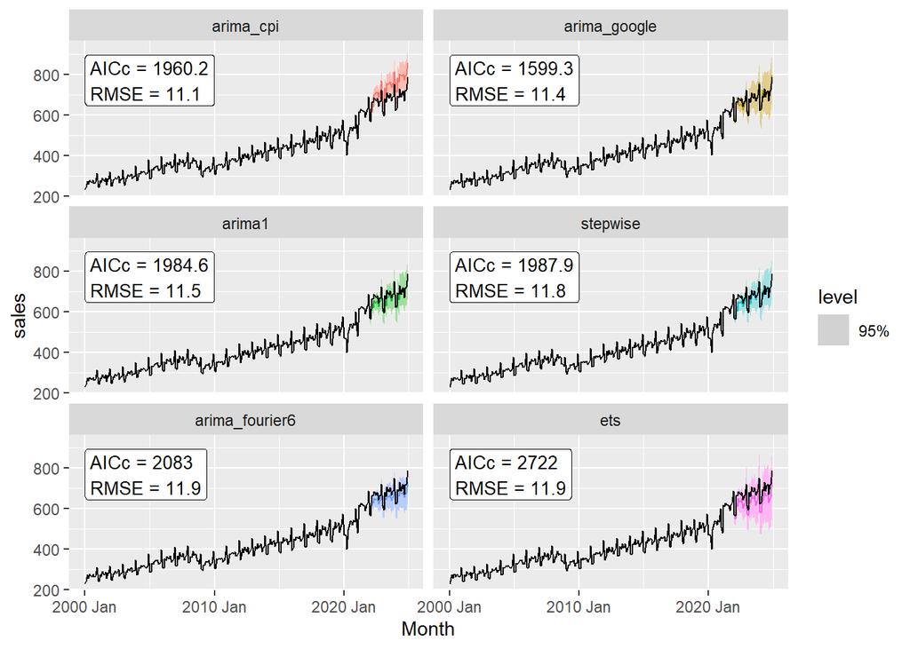

##### Test Data RMSE

```
# A tibble: 10 × 5
   .model         .type  RMSE   MAE  MAPE
   <chr>          <chr> <dbl> <dbl> <dbl>
 1 arima_google   Test   14.2  12.2  1.82
 2 arima012011    Test   15.6  11.7  1.77
 3 arima210011    Test   15.6  11.8  1.79
 4 arima1         Test   18.4  15.6  2.30
 5 stepwise       Test   19.5  14.9  2.23
 6 arima_fourier6 Test   29.5  27.2  3.95
 7 ets            Test   40.1  37.7  5.56
 8 arima210110    Test   50.5  42.3  6.18
 9 arima_cpi      Test   63.3  58.5  8.60
10 fourier6       Test  125.  124.  18.1
```

I evaluated model performance on the test set (2022–2024) using RMSE.

arima_google clearly performed the best with a test RMSE of 14.2, indicating that Google Trends data on restaurant activity is highly predictive of retail sales. The next best models were arima012011 and arima210011 (both RMSE ~15.6), showing that classical ARIMA also works well, but not as well as ARIMA with external regressors.

fourier6 and ets also had high test RMSEs (125 and 40.1 respectively), confirming they failed to generalize well.

Overall arima_google and arima are the most robust models across both training and test performance. Models with relevant external signals (like online behavior) generalize better than models relying only on time series patterns.

###### Forecasts: Top 6 Models Ranked by Test Data RMSE

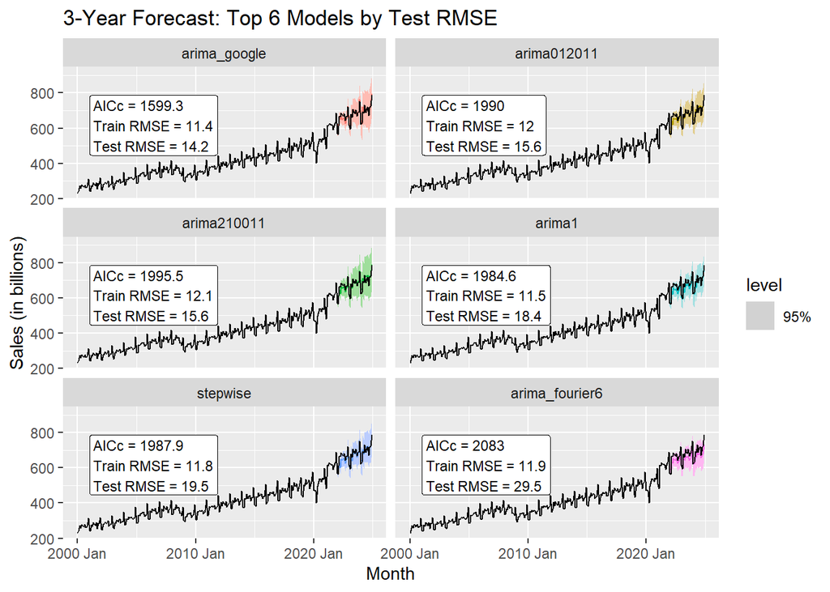

#### Evaluation of ARIMA Models with and without Google Trends

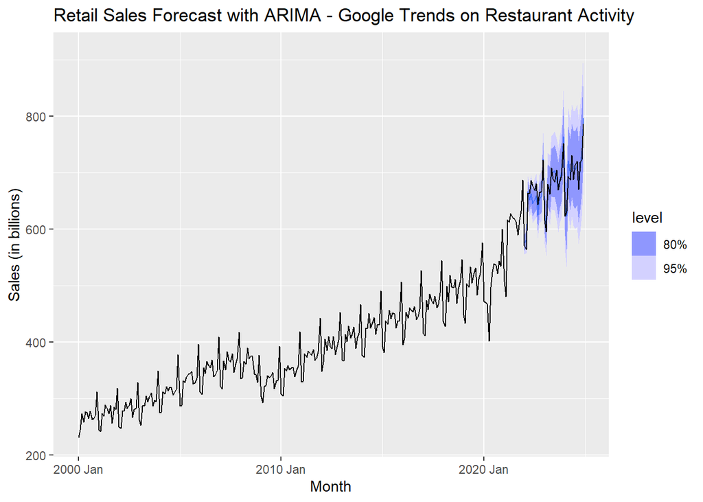

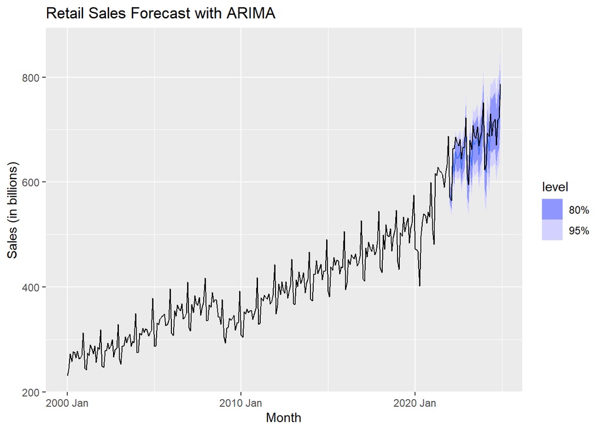

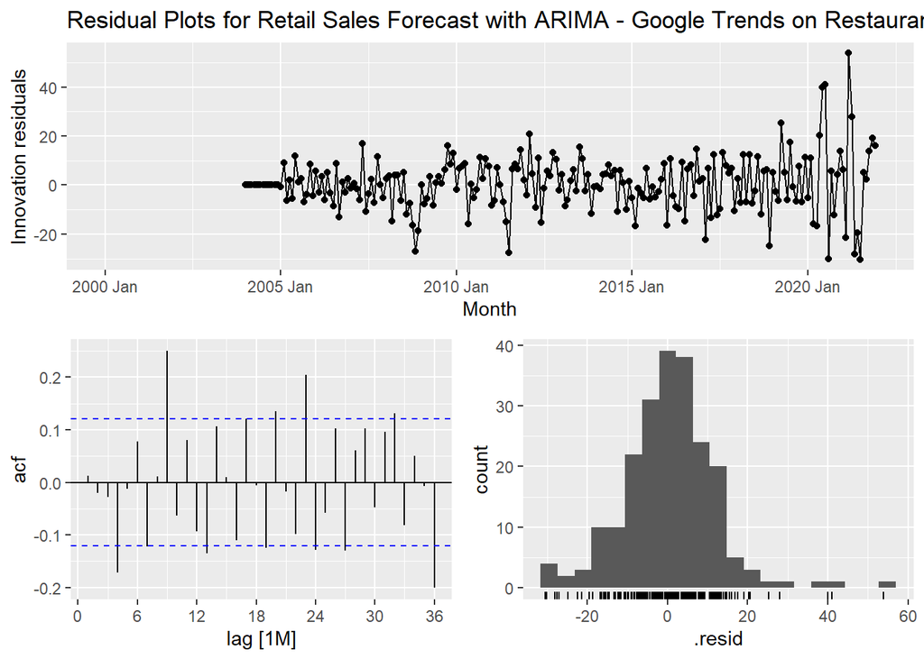

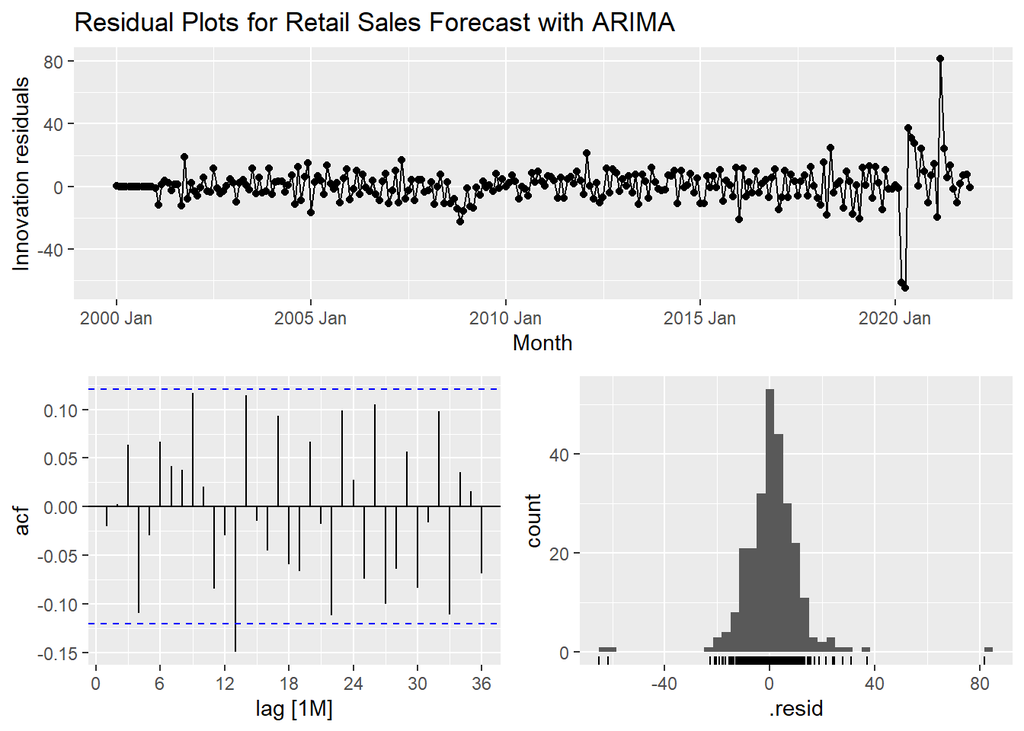

```
# A tibble: 4 × 5
  .model       .type     RMSE   MAE  MAPE
  <chr>        <chr>    <dbl> <dbl> <dbl>
1 arima_google Training  11.4  8.27  1.92
2 arima1       Training  11.5  7.37  1.84
3 arima_google Test      14.2 12.2   1.82
4 arima1       Test      18.4 15.6   2.30
```

```
# A tibble: 2 × 3
  .model       lb_stat lb_pvalue
  <chr>          <dbl>     <dbl>
1 arima_google   11.6      0.170
2 arima1          6.76     0.239
```

Both models passed key residual diagnostics:

- Residuals from arima_google show a few spikes but are mostly centered around zero, while those from arima1 are consistently centered with no clear patterns—both indicating a good model fit.
- Autocorrelation (ACF) plots show most spikes within the 95% confidence bounds, indicating no significant autocorrelation left in the residuals.
- Histograms of residuals are approximately bell-shaped, supporting the assumption of normality.
- Ljung-Box test (lag = 8) confirms that residuals behave like white noise for both models:
- arima_google: p = 0.17
- arima1: p = 0.239
- The large p-value confirms that the residuals are similar to white noise.

However, arima_google outperforms arima1 on both training and test RMSE. It also incorporates external Google Trends data, which seems to improve its predictive power. Thus, arima_google is the preferred model overall.

### Clothing and Clothing Accessory Stores

#### Train - Test Split

I split the dataset into training and test sets. All data before January 2022 was used for training, while data from January 2022 onwards was reserved for testing. This setup allows for an honest evaluation of the forecasting models’ ability to generalize.

I also visualized the training data across the three variables to observe any discrepancies in trends and seasonality, which helped validate the relationships among these features before fitting time series models.

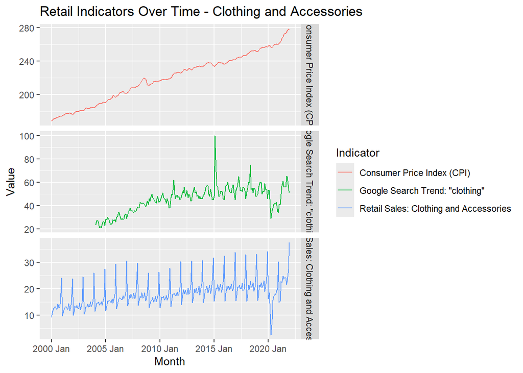

Consumer Price Index (CPI) continues to increase steadily from 2000 to 2024, consistent with long-term inflation trends and affecting clothing prices over time.

Google Trends for “clothing” shows seasonal spikes around holiday periods, with a noticeable dip during the 2020 pandemic and recovery afterward—mirroring temporary disruptions and shifts to online shopping behavior.

Retail Sales for Clothing and Accessories Stores display strong seasonality and a generally upward trend, with a sharp decline in 2020 due to COVID-19, followed by a recovery and continued growth post-pandemic.

#### Model Fitting

```
# A mable: 10 x 2
# Key:     Model name [10]
   `Model name`                                   Orders
   <chr>                                         <model>
 1 fourier6                                       <TSLM>
 2 ets                                      <ETS(A,N,A)>
 3 arima012011                 <ARIMA(0,1,2)(0,1,1)[12]>
 4 arima210011                 <ARIMA(2,1,0)(0,1,1)[12]>
 5 arima210110                 <ARIMA(2,1,0)(1,1,0)[12]>
 6 stepwise           <ARIMA(1,0,1)(0,1,1)[12] w/ drift>
 7 arima1             <ARIMA(3,0,2)(0,1,1)[12] w/ drift>
 8 arima_cpi      <LM w/ ARIMA(1,0,2)(0,1,1)[12] errors>
 9 arima_google   <LM w/ ARIMA(1,0,0)(1,1,0)[12] errors>
10 arima_fourier6            <LM w/ ARIMA(1,1,2) errors>
```

##### AIC Comparison

```
# A tibble: 10 × 6
   .model         sigma2 log_lik   AIC  AICc   BIC
   <chr>           <dbl>   <dbl> <dbl> <dbl> <dbl>
 1 fourier6         3.94   -549.  377.  378.  427.
 2 arima_google     1.68   -368.  743.  744.  757.
 3 arima_cpi        1.57   -419.  852.  852.  876.
 4 arima1           1.60   -421.  859.  859.  887.
 5 stepwise         1.65   -426.  862.  862.  880.
 6 arima012011      1.76   -433.  875.  875.  889.
 7 arima210011      1.80   -435.  879.  879.  893.
 8 arima_fourier6   1.61   -429.  888.  890.  942.
 9 arima210110      2.08   -451.  910.  910.  924.
10 ets              1.83   -809. 1647. 1649. 1701.
```

I fitted multiple models including traditional ARIMA variants, Fourier-based seasonal regression (fourier6), exponential smoothing (ETS), and ARIMA models incorporating external regressors like the Consumer Price Index (CPI) and Google Trends for the keyword “clothing”.

From the model comparison table:

Including Google Trends for “clothing” as a regressor significantly improves model performance, outperforming both CPI-based and traditional ARIMA models. This mirrors findings from the food services analysis and suggests that consumer search behavior is a strong leading indicator for clothing retail sales.

###### Forecasts: Top 6 Models Ranked by AICc

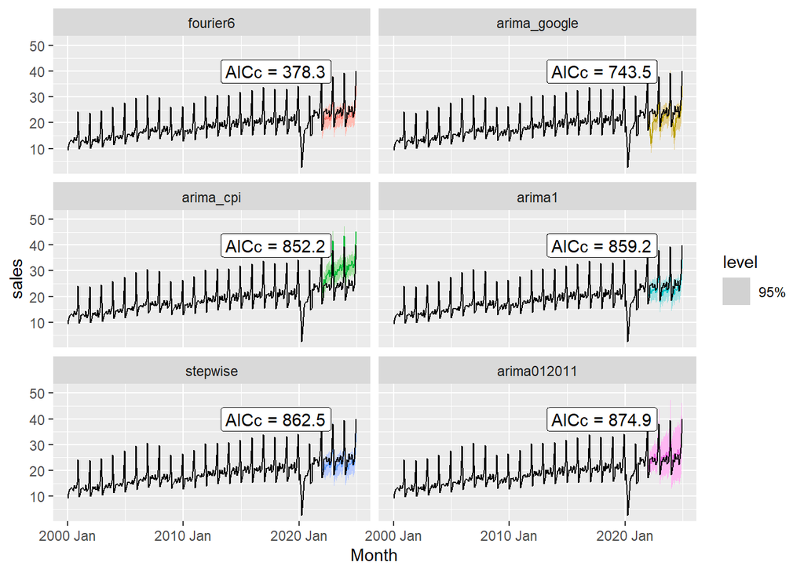

##### Training Data RMSE

```
# A tibble: 10 × 5
   .model         .type     RMSE   MAE  MAPE
   <chr>          <chr>    <dbl> <dbl> <dbl>
 1 arima_cpi      Training  1.21 0.691  4.94
 2 arima1         Training  1.22 0.654  4.88
 3 arima_fourier6 Training  1.23 0.753  5.38
 4 stepwise       Training  1.25 0.713  5.06
 5 arima012011    Training  1.29 0.709  5.06
 6 arima210011    Training  1.30 0.739  5.14
 7 ets            Training  1.32 0.787  5.67
 8 arima_google   Training  1.39 0.828  5.77
 9 arima210110    Training  1.40 0.807  5.48
10 fourier6       Training  1.94 1.08   8.52
```

I evaluated all models based on their training RMSE to assess how well they fit the historical sales data for clothing and accessory retail.

Unlike the food services category, where Google Trends was highly effective, in the clothing sector, CPI appears to be the most useful external signal. This could be because clothing purchases are more price-sensitive and influenced by macroeconomic factors than by immediate consumer search behavior.

###### Forecasts: Top 6 Models Ranked by Training Data RMSE

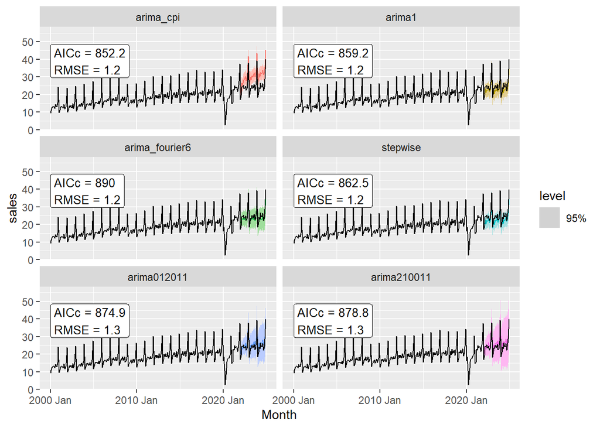

##### Test Data RMSE

```
# A tibble: 10 × 5
   .model         .type  RMSE   MAE  MAPE
   <chr>          <chr> <dbl> <dbl> <dbl>
 1 arima_fourier6 Test   1.70  1.30  5.11
 2 ets            Test   1.91  1.59  7.10
 3 arima012011    Test   1.94  1.69  7.51
 4 arima1         Test   2.01  1.71  6.67
 5 fourier6       Test   2.17  1.84  6.96
 6 stepwise       Test   2.20  1.92  7.51
 7 arima210011    Test   2.25  1.97  8.76
 8 arima210110    Test   3.97  3.14 13.2
 9 arima_google   Test   4.23  3.19 12.7
10 arima_cpi      Test   6.33  6.05 25.5
```

I evaluated model performance on the test set (2022–2024) using RMSE to assess how well each model generalizes to unseen data.

- arima_fourier6 emerged as the best performer with the lowest test RMSE of 1.70, showing that combining Fourier terms with ARIMA can effectively capture both trend and seasonal patterns in clothing retail sales.
- Close contenders included ets (RMSE = 1.91) and arima012011 (RMSE = 1.94), indicating that both exponential smoothing and classic ARIMA structures still offer solid predictive performance for this category.
- arima1, which performed well in training, had a slightly higher test RMSE of 2.01, suggesting it generalizes decently but is slightly less robust than Fourier-based or smoother ETS models.
- The basic fourier6 model (RMSE = 2.17) and stepwise ARIMA (RMSE = 2.20) were slightly weaker, likely due to limitations in capturing complex patterns without strong exogenous signals.
- Models like arima210011 and arima210110 had poorer performance (RMSE ~2.25–3.97), possibly due to overfitting or misaligned lag structures.
- Notably, arima_google and arima_cpi performed the worst, with RMSEs of 4.22 and 6.33 respectively. This suggests that Google Trends and CPI were not reliable predictors of test-period clothing sales—highlighting a key contrast to the food services domain where such signals worked well.

###### Forecasts: Top 6 Models Ranked by Test Data RMSE

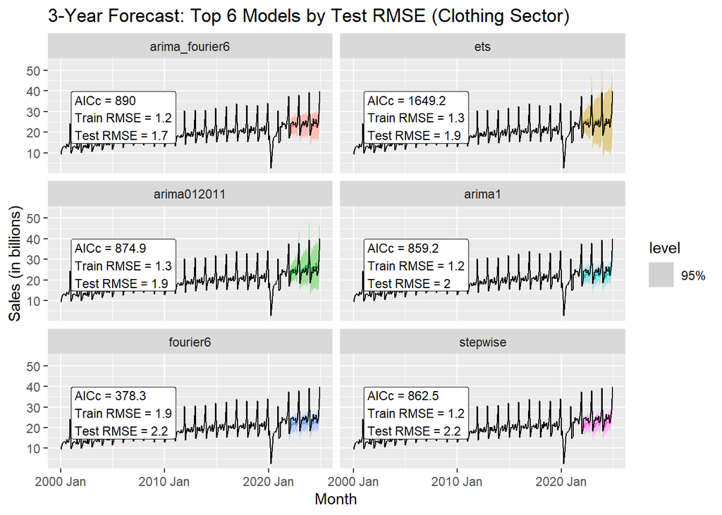